# Reproducing the Bob Ross Chart - fivethirtyeight

Shamindra Shrotriya

7/13/2018

### Setup

Let’s setup our required libraries for the data wrangling and plotting:

```r
library(devtools)

# Define packages to load
cran_pckgs <- c("here", "tidyverse", "magrittr", "DT", "ggthemes", "scales",
                "knitr")

# Install them if not on the system
# install.packages(pkgs = pckgs, dependencies = TRUE) # CRAN
devtools::install_github("hadley/emo") # EMOJI package

# Load all packages
# Source: https://blog.mitchelloharawild.com/blog/loading-r-packages-in-a-loop/
for(pkg in cran_pckgs){
  eval(bquote(library(.(pkg))))
}
```

We will mainly need `tidyverse` and `magrittr` (for ye old piping) for this exercise. The `ggthemes` package will be used to define the fivethirtyeight theme. In order to load the libraries in a clean simple loop, we will use Mitchell O’Hara-Wild’s [convenient script](https://blog.mitchelloharawild.com/blog/loading-r-packages-in-a-loop/) 😎.

## Recreating the Bob Ross chart from Fivethirtyeight

We will attempt to reproduce the Bob Ross barplot from [this fascinating fivethirtyeight article](https://fivethirtyeight.com/features/a-statistical-analysis-of-the-work-of-bob-ross/) by the author [Walt Hickey](https://fivethirtyeight.com/contributors/walt-hickey/). Specifically this is the [chart](https://fivethirtyeight.com/wp-content/uploads/2014/04/hickey-ross-tags-1.png?w=1150) we will be reproducing from the article:

[figure not shown]

We will be using the data kindly provided by the author [here](https://github.com/fivethirtyeight/data/tree/master/bob-ross). Let’s get cracking 💪.

## Acknowledgments

As always thanks to fivethirtyeight for creating such fantastic graphics to learn from and for doing the heavy lifting in obtaining and kindly providing the [underlying data and code](https://github.com/fivethirtyeight/data) for exploratory purposes. I’ve only used their data here and not looked at any code provided to enhance my own learning of `ggplot2` and `R` which is the very point of this post 😄.

### Data Load and Processing

Note we can download the data directly from the [raw source](https://raw.githubusercontent.com/fivethirtyeight/data/master/bob-ross/elements-by-episode.csv) or from local file we have saved in our submodule clone of the fivethirtyeight github repo. We will go with the latter option as we already have the data loaded and will save us unnecessary server calls to github when re-running the code.

```r
# OPTION 1 - Download raw data directly from source
# ross_url <- "https://raw.githubusercontent.com/fivethirtyeight/data/master/bob-ross/elements-by-episode.csv"
# ross_dat <- readr::read_csv(file = ross_url)

# OPTION 2 - Load data from our local directory (submodule)
core_dat_dir <- here::here("submods", "data", "bob-ross")
ross_dat <- readr::read_csv(file = file.path(core_dat_dir,
                                             "elements-by-episode.csv"))
# dir.exists(core_dat_dir) # Just checking that the data dir is valid
# dplyr::glimpse(ross_dat)
# ross_dat %>%
    # DT::datatable(data = .)
```

Interesting, so we have seem to have a unique episode identifier and associated title and then 67 indicator variables of features related to Bob Ross’ paintings e.g. `BOAT` being 1 presumably indicates that there was a painting of a boat for that particular episode.

### Tidying the data

```r
ross_tidy <- ross_dat %>%
                tidyr::gather(data = ., key = tag, value = indicator, APPLE_FRAME:WOOD_FRAMED)

# Helper function to convert strings to Title case replacing underscores with
# spaces and trimming appropriately
new_tag_fmt <- function(str){
    stringr::str_replace_all(string = str, pattern = "_",
                             replacement = " ") %>%
        stringr::str_trim() %>%
        stringr::str_to_title() %>%
        base::return()
}

tot_episodes <- ross_tidy %>% dplyr::select(EPISODE) %>% dplyr::n_distinct()
ross_tidy2 <- ross_tidy %>%
                dplyr::group_by(tag) %>%
                dplyr::summarize(total = sum(indicator)) %>%
                dplyr::ungroup() %>%
                dplyr::mutate(tag = base::as.factor(new_tag_fmt(str = tag)),
                              perc = base::round(total/tot_episodes, 2),
                              perc_fmt = scales::percent(perc)) %>%
                dplyr::arrange(desc(total)) %>%
                dplyr::filter(total >= 5)
# DT::datatable(ross_tidy2)
```

### Creating the plot

So this plot took a lot of adjustments to make. As it can be seen below there are more improvements to make but the general idea seems fine. I did reach out to stackoverflow to understand an issue I was having with positioning and the barwidth. The issue is still not quite resolved though I’m very open to suggestions and improvements 💁.

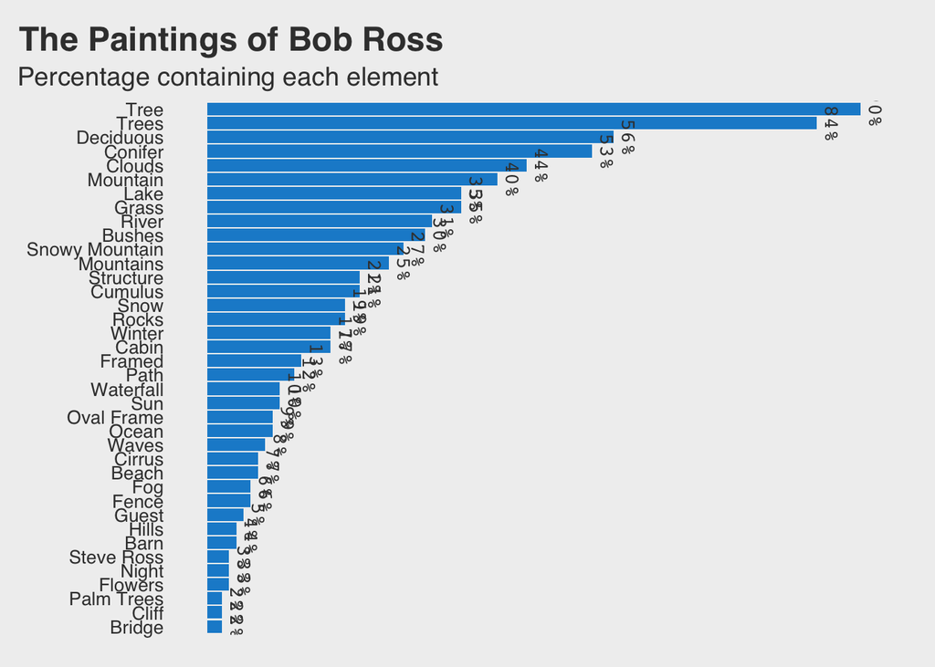

```r
ross_tidy2 %>%
    ggplot2::ggplot(data = ., aes(x = reorder(tag, perc), y = perc)) +
    ggplot2::geom_bar(stat = "identity", fill = "#198DD1",
                      position = position_dodge(width = 0.7)) +
    ggplot2::coord_flip() +
    ggplot2::labs(title = "The Paintings of Bob Ross",
                  subtitle = "Percentage containing each element") +
    ggplot2::geom_text(data = ross_tidy2, nudge_y = 0.02, angle = 270,
                           aes(reorder(tag, total), y = perc, label = perc_fmt),
                       family = "Courier", color = "#3E3E3E") +
    ggthemes::scale_color_fivethirtyeight("cyl") +
    ggthemes::theme_fivethirtyeight() +
    ggplot2::theme(panel.border = element_blank(),
                   panel.grid.major = element_blank(),
                   panel.grid.minor = element_blank(),
                   axis.line = element_blank(),
                   axis.ticks.x = element_blank(),
                   axis.text.x = element_blank(),
                   plot.title = element_text(size = 18, hjust=-0.5),
                   plot.subtitle = element_text(size = 14, hjust=-0.5),
                   axis.text.y = element_text(size = 10))
```

### Issues and Improvements

The following could clearly be improved:

- Getting access to the full `tag` data from the author would be awesome. This would then match the more granular y-axis labels in line with the article rather than the summary tags provided. Unlike the author I don’t have the stamina to autotag all of the episodes, though that would be a good validation of the source data.
- I would like to have the plot vertically enlarged i.e. stretched, much like the source graphic. *Does anyone have any idea how to make this happen to make it resemble the actual chart (which may not be produced only using `ggplot2`?*. The percentage values are not really legible and I can’t adjust the bar width and bar position to be dodged at the same time.

### Verdict - Success or Failure

So what’s the verdict - Success or Failure? *Not a complete failure* but needs more work per the improvements above.